# Säter

Jon Frank

2023-03-23

### Säter

Säter tillhör en ganska stor grupp av kommuner i Dalarna med mellan 10 000 och 11 000 invånare. Befolkningen ökade avsevärt från slutet av 1960-talet till 1990, men minskade därefter. På senare år har Säters befolkning återigen börjat öka, vilket kan tillskrivas såväl en ökning bland inrikes som utrikes födda invånare. Arbetslösheten i Säter, drygt 3 procent, är klart lägre än genomsnittet i Dalarna, samtidigt som andelen högutbildade är något lägre än genomsnittet. Att arbetslösheten är låg kan delvis tillskrivas att andelen utrikes födda i Säter, en grupp med högre arbetslöshet än inrikes födda, är relativt låg. Exempelvis har närliggande Borlänge mer än dubbelt så stor andel utrikes födda och dessutom mer än dubbelt så hög arbetslöshet. Medelåldern i Säter är relativt låg, ca 45 år, men samtidigt klart högre än näraliggande Borläne. Säter är, tillsammans med Gagnef, den kommun som har störst pendling i Dalarna, då närmare 60 procent av de som bor i Säter och förvärvsarbetar har sin arbetsplats på annan ort.

Säter fick stadsprivilegier redan på 1600-talet och är bland annat känt för Säters sjukhus, som under en period var Sveriges största mentalsjukshus. Idag jobbar en stor andel inom vård och omsorg, närmare 30 procent av de förvärvsarbetande, vilket är den högsta andelen bland Dalarnas kommuner. I övrigt är byggsektorn viktig, med en klart större andel förvärvsarbande än Dalarnas genomsnitt.

[figure not shown]

Figur 10

Antalet arbetsställen per 1000 invånare i Säter är bland det minsta i Dalarna, men samtidigt har antalet nystartade företag (per 1000 invånare) ökat under en längre period och ligger idag över Dalarnas genomsnitt.

Branschbredden i Säter är i linje med många andra kommuner av samma storlek, men antalet företag som krävs för att den aggregerade lönesumman skall uppgå till 50 procent av den totala lönesumman i det privata näringslivet (44) är avsevärt mycket större än många jämförbara kommuner. Säter kan därför sägas vara en kommun med relativt litet beroende. Samtidigt skall man vara medveten om att andelen som arbetar inom vård och omsorg i Säter (där många arbetsgivare tillhör det offentliga) är högst i Dalarna, vilket är ett annat typ av beroende.

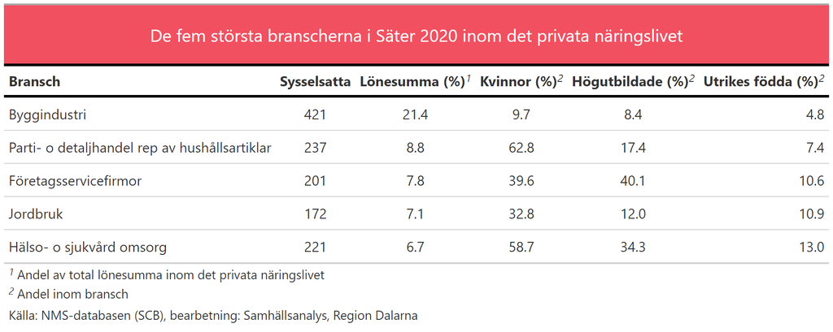

Figur 9

Sammanfattningsvis är Säter en kommun med låg sårbarhet. Arbetslöshten är låg och det sker en stor pendling till framförallt näraliggande Borlänge. Desstuom är beroendet av enskilda företag och branscher, inom den privata sektorn, lågt. På minussidan finns en stor dominans av arbetsgivare inom vård och omsorg, vilket potentiellt kan vara en sårbarhet. Det är dock rimligt att tänka sig att företag inom offentliga verksamheter påverkas annorlunda än det privata näringslivet vid exempelvis en konkjunkturnedgång, samtidigt som behovat av tjänster kopplade till vård och omsorg sannolikt kommer att öka i framtiden.